# ЕГЭ 2017 Вариант 2 EGE 2017 Variant 2

### The variant from the book was used: [ЕГЭ-2017. Информатика.10 тренировочных вариантов. Ушаков Д.М.](https://drive.google.com/file/d/0B6696ckkWj_zS2ptblAxNERHZzQ/view)

## Часть 1 Part 1

```python
%%html
<style>
@import url('https://fonts.googleapis.com/css?family=Roboto');
body {background-color: aliceblue;}
a {color: #4876ff; font-family: 'Roboto';}
h1 {color: #348ABD; font-family: 'Roboto'; text-shadow: 4px 4px 4px #aaa;}
h2, h3 {color: gray; font-family: 'Roboto'; text-shadow: 4px 4px 4px #aaa;}
h4 {color: #348ABD; font-family: 'Roboto';}
span {text-shadow: 4px 4px 4px #aaa;}
div.output_prompt, div.output_area pre, div.output_subarea {color: gray;}
div.input_prompt {color: #4876ff;}
div.output_stderr pre {background-color: aliceblue;}
div.output_stderr {background-color: gray;}
</style>
```

```python
answer_dictionary = dict()
```

[figure not shown]

Дано $A = 325_8$, $B = {D7}_{16}$.

Укажите число С, записанное в двоичной системе счисления, которое отвечает условию А < С < В.

Основание системы счисления указывать не нужно.

(Например, если ответ должен быть $1100_2$, в ответе нужно записать $1100$.)

$ A = 325_8 $, $ B = {D7}_{16} $ are given.

Specify the number C, written in the binary system, which corresponds to the condition A < C < B.

The base of the number system should not be indicated.

(For example, if the answer is $ 1100_2 $, you need to write $ 1100 $ in the answer.)

```python
# from the given systems to decimal
int('325', 8), int('D7',16)
```

```
(213, 215)
```

```python
# from decimal to bunary
answer_dictionary[1]=bin(214)[2:]
print ("Answer:",answer_dictionary[1])
```

```
Answer: 11010110
```

[figure not shown]

Дан фрагмент таблицы истинности выражения F, зависящего от трёх аргументов X, Y, Z.

Перечислите в порядке возрастания без запятых и пробелов номера логических выражений, которые соответствуют F.

A fragment of the truth table of the expression F, depending on three arguments X, Y, Z, is given.

List in ascending order without commas and spaces the numbers of logical expressions that correspond to F.

| $X$ | $Y$ | $Z$ | $F$ |
| --- | --- | --- | --- |
| 0 | 1 | 1 | 1 |
| 1 | 0 | 1 | 0 |
| 1 | 1 | 0 | 1 |

$1) \ \neg X \lor Y \land Z \\ 2) \ \neg X \land Y \land Z \\ 3) \ \neg X \lor Y \land \neg Z \\ 4) \ \neg X \land Y \lor \neg Z \\ 5) \ X \lor Y \lor \neg Z$

```python
binary_combinations = [[0,1,1,1],[1,0,1,0],[1,1,0,1]]

def f(x,y,z,i):
    if i == 1:
        return int((not x) or y and z)
    if i == 2:
        return int((not x) and y and z)
    if i == 3:
        return int((not x) or y and (not z))
    if i == 4:
        return int((not x) and y or (not z))
    if i == 5:
        return int(x or y or (not z))

answer=''

for i in range(5):

    result = []
    for (x,y,z,F) in binary_combinations:
        result.append(f(x,y,z,i+1) == F)
    print('\n', str(i+1)+')', result)
    if result == 3*[True]:
        answer = answer+str(i+1)

answer_dictionary[2]=answer
print ("\nAnswer:",answer_dictionary[2])
```

```
 1) [True, True, False]

 2) [True, True, False]

 3) [True, True, True]

 4) [True, True, True]

 5) [True, False, True]

Answer: 34
```

[figure not shown]

В таблице приведена стоимость перевозок между соседними железнодорожными станциями.

Перечислите в порядке возрастания, без пробелов и запятых, номера таблиц, соответствующих схеме.

The table shows the cost of transportation between neighboring railway stations.

List in ascending order, without spaces or commas, the numbers of tables that are corresponding to the scheme.

| $1) $ | 𒏏 | A | B | C | D | E | F |  |  | $2)$ | 𒏏 | A | B | C | D | E | F |
| --- | --- | --- | --- | --- | --- | --- | --- | --- | --- | --- | --- | --- | --- | --- | --- | --- | --- |
|  | **A** | 𒏏 | 3 |  |  |  | 2 |  |  |  | **A** | 𒏏 | 3 |  |  |  | 2 |
|  | **B** | 3 | 𒏏 | 3 | 5 |  | 4 |  |  |  | **B** | 3 | 𒏏 | 3 | 5 |  | 4 |
|  | **C** |  | 3 | 𒏏 | 3 | 5 |  |  |  |  | **C** |  | 3 | 𒏏 | 2 | 5 |  |
|  | **D** |  |  | 3 | 𒏏 | 2 |  |  |  |  | **D** |  |  | 2 | 𒏏 | 3 |  |
|  | **E** |  | 5 | 5 | 2 | 𒏏 |  |  |  |  | **E** |  | 5 | 5 | 3 | 𒏏 |  |
|  | **F** | 2 | 4 |  |  |  | 𒏏 |  |  |  | **F** | 2 | 4 |  |  |  | 𒏏 |

| $3) $ | 𒏏 | A | B | C | D | E | F |  |  | $4)$ | 𒏏 | A | B | C | D | E | F |
| --- | --- | --- | --- | --- | --- | --- | --- | --- | --- | --- | --- | --- | --- | --- | --- | --- | --- |
|  | **A** | 𒏏 | 3 |  |  |  | 2 |  |  |  | **A** | 𒏏 | 3 |  |  |  | 2 |
|  | **B** | 3 | 𒏏 | 3 | 5 |  | 4 |  |  |  | **B** | 3 | 𒏏 | 3 | 5 |  | 4 |
|  | **C** |  | 3 | 𒏏 | 2 | 5 |  |  |  |  | **C** |  | 3 | 𒏏 | 2 | 3 |  |
|  | **D** |  |  | 2 | 𒏏 |  |  |  |  |  | **D** |  |  | 2 | 𒏏 | 5 |  |
|  | **E** |  | 5 | 5 |  | 𒏏 | 3 |  |  |  | **E** |  | 5 | 3 | 5 | 𒏏 |  |
|  | **F** | 2 | 4 |  |  | 3 | 𒏏 |  |  |  | **F** | 2 | 4 |  |  |  | 𒏏 |

```python
import networkx as nx
import pandas
import matplotlib.pyplot as plt
%matplotlib inline

df = pandas.DataFrame(index=['A', 'B', 'C', 'D', 'E', 'F'],
                      columns=['A', 'B', 'C', 'D', 'E', 'F'])
df = df.fillna(0)
df['A']['B'], df['A']['F'] = 3, 2
df['B']['A'], df['B']['C'], df['B']['E'], df['B']['F'] = 3, 3, 5, 4
df['C']['B'], df['C']['D'], df['C']['E'] = 3, 2, 5
df['D']['C'], df['D']['E'] = 2, 3
df['E']['B'], df['E']['C'], df['E']['D'] = 5, 5, 3
df['F']['A'], df['F']['B'] = 2, 4
df
```

|  | A | B | C | D | E | F |
| --- | --- | --- | --- | --- | --- | --- |
| A | 0 | 3 | 0 | 0 | 0 | 2 |
| B | 3 | 0 | 3 | 0 | 5 | 4 |
| C | 0 | 3 | 0 | 2 | 5 | 0 |
| D | 0 | 0 | 2 | 0 | 3 | 0 |
| E | 0 | 5 | 5 | 3 | 0 | 0 |
| F | 2 | 4 | 0 | 0 | 0 | 0 |

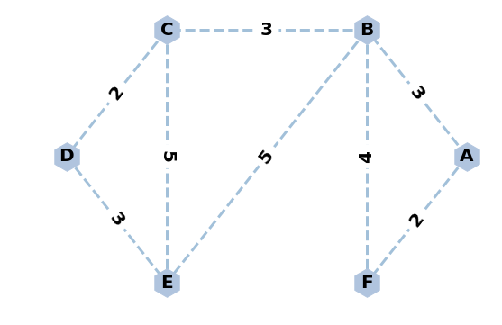

```python
plt.figure(figsize=(9,6))
G=nx.from_pandas_adjacency(df)
pos=nx.shell_layout(G)

nx.draw_networkx_nodes(G,pos,node_size=1000,node_shape="h",
                       node_color='lightsteelblue')
nx.draw_networkx_labels(G,pos,font_size=20,font_weight='bold')
nx.draw_networkx_edges(G,pos,width=3,alpha=0.5,
                       edge_color='steelblue',style='dashed')
edge_labels=\
dict([((u,v,),d['weight']) for u,v,d in G.edges(data=True)])
nx.draw_networkx_edge_labels(G,pos,font_size=20,font_weight='bold',
                             edge_labels=edge_labels)
plt.axis('off');
```

```python
answer_dictionary[3]=str(2)
print ("Answer:",answer_dictionary[3])
```

```
Answer: 2
```

[figure not shown]

В каталоге находятся шесть файлов. / There are six files in the directory.

| 1 | 2 | 3 | 4 | 5 | 6 |
| --- | --- | --- | --- | --- | --- |
| ask.c | kasko.cpp | kraska.doc | nebraska.docx | mask.pic | laska.dpr |

Ниже представлено восемь масок. / Bellow, you can see eight masks.

| `?ask*.???*` | `*ask*.*c*` | `*as??.*c*` | `*ask*.???` |
| --- | --- | --- | --- |
| `*a*a*.*d*` | `*aska*.?*?` | `?????*.???` | `?s*k?.*` |

Сколько из них таких, которым соответствует ровно три файла из данного каталога?

How many of them are those to which exactly three files from this catalog correspond?

```python
import fnmatch
import os
mask_list = ['?ask*.???*','*ask*.*c*','*as??.*c*', '*ask*.???',
             '*a*a*.*d*','*aska*.?*?','?????*.???', '?s*k?.*']
file_list = ['ask.c', 'kasko.cpp', 'kraska.doc',
             'nebraska.docx', 'mask.pic', 'laska.dpr']
answer_list = [[],[],[],[],[],[],[],[]]
c=0

for i,mask in enumerate(mask_list):
    for j,file in enumerate(file_list):
        if fnmatch.fnmatch(file, mask):
            print (i+1,mask,j+1,file)
            answer_list[i].append(str(j+1))
    if len(answer_list[i])==3:
        c+=1

print(answer_list)
answer_dictionary[4]=str(c)
print("\n","Answer:",answer_dictionary[4])
```

```
1 ?ask*.???* 2 kasko.cpp
1 ?ask*.???* 5 mask.pic
1 ?ask*.???* 6 laska.dpr
2 *ask*.*c* 1 ask.c
2 *ask*.*c* 2 kasko.cpp
2 *ask*.*c* 3 kraska.doc
2 *ask*.*c* 4 nebraska.docx
2 *ask*.*c* 5 mask.pic
3 *as??.*c* 2 kasko.cpp
3 *as??.*c* 3 kraska.doc
3 *as??.*c* 4 nebraska.docx
4 *ask*.??? 2 kasko.cpp
4 *ask*.??? 3 kraska.doc
4 *ask*.??? 5 mask.pic
4 *ask*.??? 6 laska.dpr
5 *a*a*.*d* 3 kraska.doc
5 *a*a*.*d* 4 nebraska.docx
5 *a*a*.*d* 6 laska.dpr
6 *aska*.?*? 3 kraska.doc
6 *aska*.?*? 4 nebraska.docx
6 *aska*.?*? 6 laska.dpr
7 ?????*.??? 2 kasko.cpp
7 ?????*.??? 3 kraska.doc
7 ?????*.??? 6 laska.dpr
[['2', '5', '6'], ['1', '2', '3', '4', '5'], ['2', '3', '4'], ['2', '3', '5', '6'], ['3', '4', '6'], ['3', '4', '6'], ['2', '3', '6'], []]

 Answer: 5
```

```python
for mask in mask_list:
    print(fnmatch.translate(mask))
```

```
(?s:.ask.*\.....*)\Z
(?s:.*ask.*\..*c.*)\Z
(?s:.*as..\..*c.*)\Z
(?s:.*ask.*\....)\Z
(?s:.*a.*a.*\..*d.*)\Z
(?s:.*aska.*\...*.)\Z
(?s:......*\....)\Z
(?s:.s.*k.\..*)\Z
```

[figure not shown]

Для 5 букв латинского алфавита заданы их двоичные коды. Эти коды представлены в таблице.

For 5 letters of the Latin alphabet their binary codes are given. These codes are presented in the table.

| A | B | C | D | E |
| --- | --- | --- | --- | --- |
| `00` | `100` | `110` | `01` | `101` |

Определите, какой набор букв закодирован двоичной последовательностью `110011000011010101`.

В ответе запишите последовательность букв без запятых.

Determine which set of letters is encoded with the binary sequence `110011000011010101`.

In the answer, write down the sequence of letters without commas.

```python
string = '110011000011010101'
result=''
translate_dictionary = dict({'110':'C', '101':'E', '100':'B', '01':'D', '00':'A'})

while string !='':
    if string[:3] in translate_dictionary.keys():
        result+=translate_dictionary[string[:3]]
        string = string[3:]
    if string[:2] in translate_dictionary.keys():
        result+=translate_dictionary[string[:2]]
        string = string[2:]

answer_dictionary[5]=result
print("\n","Answer:",answer_dictionary[5])
```

```
 Answer: CDBACED
```

[figure not shown]

Автомат получает на вход два двузначных шестнадцатеричных числа.

В этих числах все цифры не превосходят цифру 6 (если в числе есть цифра больше 6, автомат отказывается работать).

По этим числам строится новое шестнадцатеричное число по следующим правилам.

1. Вычисляются два шестнадцатеричных числа — сумма старших разрядов полученных чисел и сумма младших разрядов этих чисел.
2. Полученные два шестнадцатеричных числа записываются друг за другом в порядке убывания (без разделителей).

*Пример.* Исходные числа: 25, 66. Поразрядные суммы: 8, В. Результат: В8.

Какие из предложенных чисел могут быть результатом работы автомата?

Перечислите в алфавитном порядке буквы, соответствующие этим числам, без пробелов и знаков препинания.

**A) 127 B) C6 C) BA D) E3 E) D1**

The machine receives two two-digit hexadecimal numbers.

In these numbers, all figures do not exceed 6 (if the number is greater than 6, the machine refuses to work).

For these numbers, a new hexadecimal number is constructed according to the following rules.

1. Two hexadecimal numbers are calculated - the sum of the highest digits of the obtained numbers and the sum of the lowest digits of these numbers.
2. The received two hexadecimal numbers are written one after the other in descending order (without separators).

*Example.* Initial numbers: 25, 66. Bitwise sums: 8, B. Result: B8.

Which of the suggested numbers can be the result of the operation of the machine?

List in alphabetical order the letters corresponding to these numbers, without spaces and punctuation marks.

**A) 127 B) C6 C) BA D) E3 E) D1**

Рассмотрим предложенные варианты:

- A) **127**
  - Цифры складываемых чисел не превышают $6_{10} \ ( 6_{16})$ => их поразрядные суммы не превышают $6_{10} + 6_{10} = 12_{10} \ ( 6_{16} + 6_{16} = C_{16} )$ => результат не может быть трехзначным в шестнадцатеричной системе.
- B) **C6**
  - Возможный вариант сложения и перестановки цифр: $26_{16}$ и $46_{16}$ поразрядно суммируются и получается пара $6_{16}, C_{16}$, затем цифры переставляются $C6_{16}$.
- C) **BA**
  - Возможный вариант сложения и перестановки цифр: $55_{16}$ и $56_{16}$ поразрядно суммируются и получается пара $A_{16}, B_{16}$, затем цифры переставляются $BA_{16}$.
- D) **E3**
  - $14_{10} \ ( E_{16})$ не может быть получена сложением двух цифр, не превышающих $6_{10} \ ( 6_{16})$.
- E) **D1**
  - $13_{10} \ ( D_{16})$ не может быть получена сложением двух цифр, не превышающих $6_{10} \ ( 6_{16})$.

Let's consider the offered variants:

- A) **127** - The digits do not exceed $6_{10} \ (6_{16})$ => their bitwise sums do not exceed $6_{10} + 6_{10} = 12_{10} \ (6_{16} + 6_{ 16} = C_{16})$ => the result cannot be a three-digit number in the hexadecimal system.
- B) **C6** - A possible variant of adding and rearranging the numbers: $26_{16}$ and $46_{16}$ are digitally summed and the pair $6_{16}, C_{16}$ is obtained, then the digits are rearranged $C6_{16}$.
- C) **BA** - A possible variant of adding and rearranging numbers: $55_{16}$ and $56_{16}$ are digitally summed and the pair $A_{16}, B_{16}$ is obtained, then the digits are rearranged $BA_{16}$.
- D) **E3** - $14_{10} \ (E_{16})$ cannot be obtained by adding two digits not exceeding $6_{10} \ (6_{16})$.
- E) **D1** - $13_{10} \ (D_{16})$ cannot be obtained by adding two digits not exceeding $6_{10} \ (6_{16})$.

```python
answer_dictionary[6]='BC'
print("\n","Answer:",answer_dictionary[6])
```

```
 Answer: BC
```

[figure not shown]

При работе с электронной таблицей в ячейку С3 записана формула: `=$B3+C$2`.

Какой вид приобретёт формула, после того как ячейку С3 скопируют в ячейку D2?

When working with a spreadsheet, the following formula is written to cell C3: `=$B3+C$2`.

What view will the formula get after the cell C3 is copied into the cell D2?

[figure not shown]

[Google Sheet](https://drive.google.com/open?id=15cVwTSZcQXGLU83RAiDptIFrWVRgaBsS5YZ39uj8jwc)

```python
answer_dictionary[7]='=$B2+D$2'
print("\n","Answer:",answer_dictionary[7])
```

```
 Answer: =$B2+D$2
```

[figure not shown]

Определите, что будет напечатано в результате выполнения следующего фрагмента программы.

Python

R

```python
k, s = 2, 8

while s < 500:
    s += 20
    k += 5

print(k)
```

```r
k <- 2
s <- 8

while (s < 500) {
    s <- s + 20
    k <- k +5
}

print(k)
```

Determine what will be printed as a result of the next program fragment.

```python
k, s = 2, 8

while s < 500:
    s += 20
    k += 5

print(k)
```

```
127
```

```python
answer_dictionary[8]=str(k)
print("\n","Answer:",answer_dictionary[8])
```

```
 Answer: 127
```

[figure not shown]

Какой объём на диске (в Мбайт) будет занимать неупакованное $16$-цветное изображение,

содержащее изображение размером $2048*1024$ пикселей?

В ответе запишите только целое число, единицу измерения писать не нужно.

What volume on the disk (in Mbytes) will be occupied by the unpacked $16$-color image

with the size of $2048 * 1024$ pixels?

In the answer, write down only an integer, you do not need to write a unit of measurement.

1) $\log_{2}{16} = 4$ (бита) - необходимо для кодирования одного пикселя 16-цветного изображения.

2) $2048 * 1024 * 4 = 2^{11} * 2^{10} * 2^2 = 2^{23}$ (бита) - необходимо для кодирования изображения размером 2048 * 1024 пикселей.

3) $2^{23} \ / \ 2^{3} = 2^{20}$ (байта) - необходимо для кодирования изображения размером 2048 * 1024 пикселей.

4) $2^{20} \ / \ 2^{20} = 1$ (Mбайт) - необходимо для кодирования изображения размером 2048 * 1024 пикселей.

1) $\log_{2} {16} = 4$ (bit) - necessary to encode one pixel of the 16-color image.

2) $2048 * 1024 * 4 = 2^{11} * 2^{10} * 2^2 = 2^{23}$ (bit) - needed to encode an image with the size of 2048 * 1024 pixels.

3) $2^{23} \ / \ 2^{3} = 2^{20}$ (byte) - needed to encode an image with the size of 2048 * 1024 pixels.

4) $2^{20} \ / \ 2^{20} = 1$ (Mbytes) - needed to encode an image with the size of 2048 * 1024 pixels.

```python
import math

bits_for_one_pixel_16_colors = int(math.log(16,2))
bits_for_image_2048_1024 = 2048 * 1024 * bits_for_one_pixel_16_colors
bytes_for_image_2048_1024 = int(bits_for_image_2048_1024 / 2**3 )
Mbytes_for_image_2048_1024 = int(bytes_for_image_2048_1024 / 2**20)

answer_dictionary[9]=str(Mbytes_for_image_2048_1024)
print("\n","Answer:",answer_dictionary[9])
```

```
 Answer: 1
```

[figure not shown]

Петя и Вася передают друг другу сообщения, используя трёхцветный фонарик.

На фонарике имеется три кнопки, соответствующие цвету,

которым будет светить фонарик (*красный*, *зелёный* и *синий*).

Две кнопки одновременно нажать нельзя.

Для передачи сообщения мальчики последовательно нажимают одну из этих кнопок пять раз.

Сколько различных сообщений могут передать мальчики?

Petya and Vasya transmit messages to each other using a tri-color flashlight.

On the flashlight there are three buttons corresponding to the color

that the flashlight will shine (*red*, *green* and *blue*).

Two buttons cannot be pressed simultaneously.

To transmit the message, the boys consistently press one of these buttons five times.

How many different messages can the boys transmit?

Каждый из 5 последовательных сигналов может принимать

3 различных значения (*красный*, *зелёный* и *синий*), независимо от других сигналов.

Значит, количество вариантов сообщений будет равно $3 * 3 * 3 * 3 * 3 = 3^{5} = 243$

Each of 5 consecutive signals can take

3 different values (*red*, *green* and *blue*), regardless of other signals.

Hence, the number of message variants will be equal to $3 * 3 * 3 * 3 * 3 = 3^{5} = 243$

```python
answer_dictionary[10]=str(3**5)
print("\n","Answer:",answer_dictionary[10])
```

```
 Answer: 243
```

[figure not shown]

Алгоритм вычисления значения функции `F(n)`, где `n` — натуральное число, задан следующими соотношениями:

- `F(n) = F(n - 1) + F(n - 2), при n > 2`
- `F(1) = F(2) = 1`

Чему равно значение функции `F(8)`?

(В ответе запишите только натуральное число.)

The algorithm for calculating the value of the function `F(n)`, where `n` is a natural number, is given by the following relations:

- `F(n) = F(n - 1) + F(n - 2), for n > 2`
- `F(1) = F(2) = 1`

What is the value of the function `F(8)`?

(In the answer write down only a positive integer number.)

```python
def F(n):
    if n==1 or n==2: return 1
    if n>2: return F(n - 1) + F(n - 2)

answer_dictionary[11]=str(F(8))
print("\n","Answer:",answer_dictionary[11])
```

```
 Answer: 21
```

[figure not shown]

Доступ к файлу `www.com`, находящемуся на сервере `http.txt`, осуществляется по протоколу `ftp`.

В таблице фрагменты адреса файла закодированы буквами от А до G.

Запишите последовательность этих букв, кодирующую адрес указанного файла.

| A | B | C | D | E | F | G |
| --- | --- | --- | --- | --- | --- | --- |
| `://` | `www` | `.txt` | `http` | `ftp` | `.com` | `/` |

Access to the file `www.com`, located on the server `http.txt`, is performed using the `ftp` protocol.

In the table, fragments of the file address are encoded with letters from A to G.

Write down the sequence of these letters coding the address of the specified file.

```python
text = 'ftp://http.txt/www.com'
translate_dictionary = dict({'://':'A', 'www':'B', '.txt':'C', 'http':'D', 'ftp':'E', '.com':'F', '/':'G'})
for i, j in translate_dictionary.items():
    text = text.replace(i, j)
answer_dictionary[12]=text
print("\n","Answer:",answer_dictionary[12])
```

```
 Answer: EADCGBF
```

[figure not shown]

В велокроссе участвует 60 спортсменов.

Автоматическое устройство кодирует номер каждого спортсмена минимально возможным и одинаково целым количеством бит.

Финишировали 30 спортсменов.

Определите информационный объём (в битах), отводимой памятью устройства для записи результатов всех финишировавших спортсменов.

In the bicycle marathon, 60 athletes participate.

The automatic device encodes the number of each athlete with the minimum possible and equally integer number of bits.

30 athletes have reached the finish.

Determine the information capacity (in bits) allocated by the device's memory to record the results of all athletes who have completed the marathon.

1) $5 < \log_{2}{60} < 6$ => 6 (бит) - необходимо для кодирования номера одного из 60 спортсменов.

Количество возможных вариантов кодировки ($2^6$) не должно быть меньше количества имеющейся информации ($60$ номеров), округление в данном случае - всегда в большую сторону.

2) $6 * 30 = 180$ (бит) - необходимо для кодирования номеров 30 спортсменов.

1) $5 < \log_{2}{60} < 6$ => 6 (bit) - necessary to encode the number of one of 60 athletes.

The number of possible encoding options ($2^6$) should not be less than the amount of information available ($60$ numbers), rounding, in this case, is always on the larger side.

2) $6 * 30 = 180$ (bit) - necessary for encoding the numbers of 30 athletes.

```python
bits_for_one_athlet_from_60 = math.ceil(math.log(60,2))
answer_dictionary[13]=str(30*bits_for_one_athlet_from_60)
print("\n","Answer:",answer_dictionary[13])
```

```
 Answer: 180
```

[figure not shown]

Система команд исполнителя РОБОТ, «живущего» в прямоугольном лабиринте на клетчатой плоскости:

The command system of the performer ROBOT, "living" in a rectangular labyrinth on the grid plane:

| вверх |  |  |  | вниз |  |  |  | влево |  |  |  | вправо |  |  |  |
| --- | --- | --- | --- | --- | --- | --- | --- | --- | --- | --- | --- | --- | --- | --- | --- |
| up |  |  |  | down |  |  |  | left |  |  |  | right |  |  |  |

При выполнении этих команд РОБОТ перемещается на одну клетку соответственно:

When these commands are executed, the ROBOT moves one cell accordingly:

| вверх ↑ |  |  |  | вниз ↓ |  |  |  | влево ← |  |  |  | вправо → |  |  |  |
| --- | --- | --- | --- | --- | --- | --- | --- | --- | --- | --- | --- | --- | --- | --- | --- |
| up ↑ |  |  |  | down ↓ |  |  |  | left ← |  |  |  | right → |  |  |  |

Четыре команды проверяют истинность условия отсутствия стены у той клетки, где находится РОБОТ:

Four commands verify the truth of the condition of the absence of the wall near the cell where the ROBOT is located:

| сверху свободно |  |  |  | снизу свободно |  |  |  | слева свободно |  |  |  | справа свободно |  |  |  |
| --- | --- | --- | --- | --- | --- | --- | --- | --- | --- | --- | --- | --- | --- | --- | --- |
| up free |  |  |  | down free |  |  |  | left free |  |  |  | right free |  |  |  |

Цикл выполняется, пока условие истинно, иначе происходит переход на следующую строку.

The loop is executed as long as the condition is true, otherwise it will jump to the next line.

Сколько клеток приведённого лабиринта соответствует требованию, что, выполнив предложенную ниже программу, РОБОТ остановится в той же клетке, с которой он начал движение?

How many cells of the given labyrinth correspond to the requirement that, after completing the program below, ROBOT will stop in the same cell with which it started moving?

- НАЧАЛО
  - ПОКА `< сверху свободно >` вправо
  - ПОКА `< справа свободно >` вниз
  - ПОКА `< снизу свободно >` влево
  - ПОКА `< слева свободно >` вверх
- КОНЕЦ
- START
  - WHILE `< up free >` right
  - WHILE `< right free >` down
  - WHILE `< down free >` left
  - WHILE `< left free >` up
- END

```python
from PIL import Image, ImageDraw

image = Image.new(mode='RGB', size=(305, 305), color='aliceblue')
draw = ImageDraw.Draw(image)

y_start, y_end = 0, image.height-5
x_start, x_end = 0, image.width-5
step_size = int((image.width-5)/6)

for x in range(0, image.width, step_size):
    if x==0 or x==300: w,f=2,'darkblue'
    else: w,f=1,'slategray'

    line = ((x, y_start), (x, y_end))
    draw.line(line, fill=f, width=w)

for y in range(0, image.height, step_size):
    if y==0 or y==300: w,f=2,'darkblue'
    else: w,f=1,'slategray'

    line = ((x_start, y), (x_end, y))
    draw.line(line, fill=f, width=w)

lines = [[(250, 0), (250, 50)], [(250, 150), (250, 200)], [(50, 50), (50, 100)],
         [(200, 100), (250, 100)], [(200, 250), (250, 250)], [(200, 50), (200, 100)],
         [(200, 200), (200, 250)], [(150, 50), (200, 50)], [(150, 250), (150, 300)],
         [(100, 100), (100, 150)], [(100, 200), (100, 250)], [(100, 200), (150, 200)],
         [(50, 250), (100, 250)], [(0, 150), (50, 150)], [(50, 100), (100, 100)]]

for line in lines:
    draw.line(line, fill='darkblue', width=2)

draw.rectangle([(55, 55), (95, 95)], fill='lightgreen')
draw.rectangle([(5, 55), (45, 95)], fill='lightgreen')
draw.rectangle([(5, 105), (45, 145)], fill='lightgreen')
draw.rectangle([(105, 105), (145, 145)], fill='lightgreen')
draw.rectangle([(5, 205), (45, 245)], fill='lightgreen')
draw.rectangle([(5, 255), (45, 295)], fill='lightgreen')
draw.rectangle([(155, 255), (195, 295)], fill='lightgreen')
draw.rectangle([(255, 155), (295, 195)], fill='lightgreen')
draw.rectangle([(205, 205), (245, 245)], fill='lightgreen')
draw.rectangle([(205, 55), (245, 95)], fill='lightgreen')
draw.rectangle([(5, 5), (45, 45)], fill='lightgreen')
draw.rectangle([(5, 155), (45, 195)], fill='lightgreen')
draw.rectangle([(255, 5), (295, 45)], fill='lightgreen')
draw.rectangle([(105, 205), (145, 245)], fill='lightgreen')

del draw
```

Выполнение последнего прекращается, если условие `<слева свободно>` ложно.

Подходят только те клетки, у которых слева есть стена:

A1, A2, A3, A4, A5, A6, B5, C2, C4, D1, E2, E5, F3, F6.

Проверим для каждой из них, вернуться ли они в исходную клетку после выполнения программы.

The execution of the program terminates if the last loop condition `<left is free>` is false.

Only those cells that have a wall on their left side are suitable:

A1, A2, A3, A4, A5, A6, B5, C2, C4, D1, E2, E5, F3, F6.

Let's check for each of them whether ROBOT returns to the start cell after the program is executed.

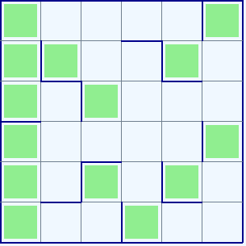

```python
image
```

Рассмотрим первый ряд клеток:

- A1 -> B1 (1 цикл); стоп.
- A2 -> B2 (1 цикл); B2 -> B3 -> B4 (4 цикл); стоп.
- A3 -> A2 -> A1 (2 цикл); стоп.
- A4 -> B4 (1 цикл); B4 -> A4 (3 цикл); стоп. ⚡
- A5 стоп.
- A6 -> A5 (2 цикл); стоп.

Аналогично находим другие клетки, для которых стартовая позиция совпадает с конечной:

- B5 -> C5 -> D5 (1 цикл); D5 -> C5 -> B5 (3 цикл); стоп. ⚡
- C4 -> D4 -> E4 (1 цикл); E4 -> E3 (2 цикл); E3 -> D3 -> C3 (3 цикл); C3 -> C4 (4 цикл); стоп. ⚡
- C2 -> C1 (2 цикл); C1 -> C2 (4 цикл); стоп. ⚡

Let's look at the first line of cells:

- A1 -> B1 (1 loop); stop.
- A2 -> B2 (1 loop); B2 -> B3 -> B4 (4 loop); stop.
- A3 -> A2 -> A1 (2 loop); stop.
- A4 -> B4 (1 loop); B4 -> A4 (3 loop); stop. ⚡
- A5 stop.
- A6 -> A5 (2 loop); stop.

Similarly, let's find other cells for which the starting position coincides with the final position:

- B5 -> C5 -> D5 (1 loop); D5 -> C5 -> B5 (3 loop); stop. ⚡
- C4 -> D4 -> E4 (1 loop); E4 -> E3 (2 loop); E3 -> D3 -> C3 (3 loop); C3 -> C4 (4 loop); stop. ⚡
- C2 -> C1 (2 loop); C1 -> C2 (4 loop); stop. ⚡

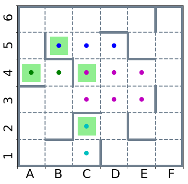

```python
plt.figure(figsize=(6,6))

hlines = [[0.04,0,1],[5.96,0,1],[3,0,0.16],
          [1,0.17,0.33],[4,0.17,0.33],[2,0.34,0.5],
          [5,0.5,0.66],[1,0.67,0.83],[4,0.67,0.83],]
for line in hlines:
    plt.axhline(line[0],line[1],line[2],
                lw=5, c='slategray')

vlines = [[0.04,0,1],[5.97,0,1],[3,0,0.16],
          [2,0.17,0.33],[2,0.5,0.67],[1,0.67,0.83],
          [4,0.17,0.33],[4,0.67,0.83],[5,0.34,0.5],[5,0.84,1]]
for line in vlines:
    plt.axvline(line[0],line[1],line[2],
                lw=5, c='slategray')

plt.scatter([1.5,2.5,0.5,2.5],[4.5,3.5,3.5,1.5],1300,'lightgreen', marker='s')
plt.scatter([1.5,2.5,3.5,2.5,3.5,4.5,4.5,3.5,2.5,0.5,1.5,2.5,2.5],
            [4.5,4.5,4.5,3.5,3.5,3.5,2.5,2.5,2.5,3.5,3.5,0.5,1.5],
            70,
            ['b','b','b','m','m','m','m','m','m','g','g','c','c'])

plt.xlim(0,6)
plt.ylim(0,6)

plt.xticks(visible=False)
plt.yticks(visible=False)
plt.xlabel(' A     B     C     D     E     F ', fontsize=25)
plt.ylabel(' 1     2     3     4     5     6 ', fontsize=25)

plt.grid(c='slategray', ls='--', lw=2)
```

```python
answer_dictionary[14]=str(4)
print("\n","Answer:",answer_dictionary[14])
```

```
 Answer: 4
```

[figure not shown]

На рисунке — схема дорог, связывающих города А, Б, В, Г, Д, Е, Ж, И, К.

По каждой дороге можно двигаться только в одном направлении, указанном стрелкой.

Сколько существует различных путей из города А в город К?

In the figure, there is a scheme of roads connecting the cities А, Б, В, Г, Д, Е, Ж, И, К.

For each road, it is possible to move only in one direction, indicated by the arrow.

How many different paths exist from the city А to the city К?

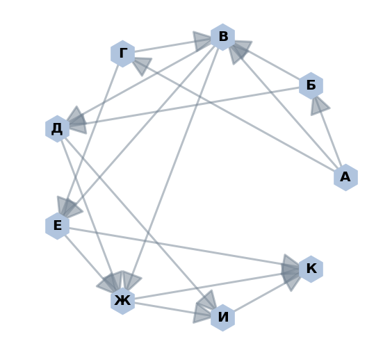

```python
G2 = nx.MultiDiGraph()
plt.figure(figsize=(9,9))

G2.add_edges_from([('А', 'Б'),('А','В'),('А','Г')])
G2.add_edges_from([('Б','В'),('Б','Д')])
G2.add_edges_from([('В','Д'),('В','Е'),('В','Ж')])
G2.add_edges_from([('Г','В'),('Г','Е')])
G2.add_edges_from([('Д','И'),('Д','Ж')])
G2.add_edges_from([('Е','Ж'),('Е','К')])
G2.add_edges_from([('Ж','И'),('Ж','К')])
G2.add_edges_from([('И','К')])

pos=nx.shell_layout(G2)

nx.draw_networkx_edges(G2, pos, width=3, alpha=0.5, edge_color='slategray',
                       arrowsize=70, arrowstyle='-|>')
nx.draw_networkx_nodes(G2, pos, node_size=1500, node_shape='h', node_color='lightsteelblue')
nx.draw_networkx_labels(G2, pos, font_size=20, font_weight='bold')

plt.axis('off')
plt.show()
```

```python
for path in nx.all_simple_paths(G2, 'А', 'К'): print (path)
```

```
['А', 'Б', 'В', 'Д', 'И', 'К']
['А', 'Б', 'В', 'Д', 'Ж', 'И', 'К']
['А', 'Б', 'В', 'Д', 'Ж', 'К']
['А', 'Б', 'В', 'Е', 'Ж', 'И', 'К']
['А', 'Б', 'В', 'Е', 'Ж', 'К']
['А', 'Б', 'В', 'Е', 'К']
['А', 'Б', 'В', 'Ж', 'И', 'К']
['А', 'Б', 'В', 'Ж', 'К']
['А', 'Б', 'Д', 'И', 'К']
['А', 'Б', 'Д', 'Ж', 'И', 'К']
['А', 'Б', 'Д', 'Ж', 'К']
['А', 'В', 'Д', 'И', 'К']
['А', 'В', 'Д', 'Ж', 'И', 'К']
['А', 'В', 'Д', 'Ж', 'К']
['А', 'В', 'Е', 'Ж', 'И', 'К']
['А', 'В', 'Е', 'Ж', 'К']
['А', 'В', 'Е', 'К']
['А', 'В', 'Ж', 'И', 'К']
['А', 'В', 'Ж', 'К']
['А', 'Г', 'В', 'Д', 'И', 'К']
['А', 'Г', 'В', 'Д', 'Ж', 'И', 'К']
['А', 'Г', 'В', 'Д', 'Ж', 'К']
['А', 'Г', 'В', 'Е', 'Ж', 'И', 'К']
['А', 'Г', 'В', 'Е', 'Ж', 'К']
['А', 'Г', 'В', 'Е', 'К']
['А', 'Г', 'В', 'Ж', 'И', 'К']
['А', 'Г', 'В', 'Ж', 'К']
['А', 'Г', 'Е', 'Ж', 'И', 'К']
['А', 'Г', 'Е', 'Ж', 'К']
['А', 'Г', 'Е', 'К']
```

```python
answer_dictionary[15]=str(len(list(nx.all_simple_paths(G2, 'А', 'К'))))
print("Answer:", answer_dictionary[15])
```

```
Answer: 30
```

[figure not shown]

Укажите через запятую в порядке возрастания все основания систем счисления,

в которых запись числа 32 оканчивается на 4.

Indicate with separating by commas in ascending order all the bases of number systems,

in which the record of the number 32 ends with 4.

По условию, основания системы счисления должны быть:

- больше 4,
- множителями числа 32 - 4 = 28.

According to the task conditions, the bases of the number systems should be: - more than 4, - multipliers of the number 32 - 4 = 28.

```python
result = ''
for i in range(10, 0, -1):
    n = (32 - 4) / i
    if int(n) == n and n > 4:
        result += str(int(n)) + ','

answer_dictionary[16] = result[:-1]
print("Answer:", answer_dictionary[16])
```

```
Answer: 7,14,28
```

[figure not shown]

В языке запросов к поисковому серверу для обозначения

- логической операции $«ИЛИ»$ используется символ $\large{\mid}$,
- а для логической операции $«И»$ — $\&$.

В таблице приведено количество страниц, которое находит поисковая система по каждому запросу.

| $\textbf {Запрос}$ | $\textbf {Количество найденных страниц}$ |
| --- | --- |
| $\textbf {Яблоки}$ | $\textbf {7300}$ |
| $\textbf {Яблоки} \mid \textbf {Сливы}$ | $\textbf {14800}$ |
| $\textbf {Яблоки & Сливы}$ | $\textbf {1400}$ |

Какое количество страниц будет найдено по запросу: $\textbf {Сливы}$?

Считается, что все запросы выполнялись практически одновременно,

так что набор страниц, содержащих все искомые слова, не изменялся за время выполнения запросов.

In the query language to the search server,

- the symbol $\large{\mid}$ is used to indicate the logical operation $OR$,
- and for the logical operation $AND$ - $\&$.

The table shows the number of pages that the search engine finds for each query.

| $\textbf {Request}$ | $\textbf {Number of pages found}$ |
| --- | --- |
| $\textbf {Apples}$ | $\textbf {7300}$ |
| $\textbf{Apples} \mid \textbf{Plums}$ | $\textbf {14800}$ |
| $\textbf {Apples & Plums}$ | $\textbf {1400}$ |

How many pages will be found on the query: $\textbf {Plums}$?

It is assumed that all queries were executed almost simultaneously

so that the set of pages containing all the searched words did not change during the execution of queries.

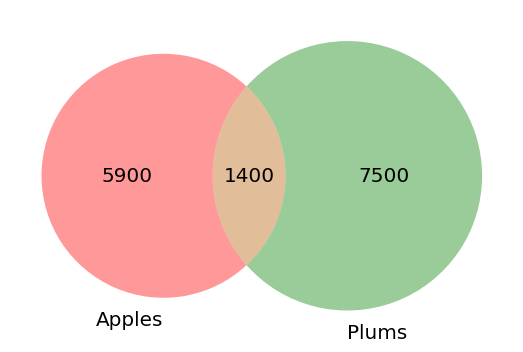

```python
from matplotlib_venn import venn2

apples = 7300
apples_and_plums = 1400
apples_or_plums = 14800

# яблоки + сливы = яблоки_или_сливы + яблоки_и_сливы
# apples + plums = apples_or_plums + apples_and_plums

plums = apples_or_plums + apples_and_plums - apples
search_sets =[apples - apples_and_plums, plums - apples_and_plums, apples_and_plums]

plt.figure(figsize=(9,9))
v=venn2(subsets=search_sets, set_labels=('Apples', 'Plums'))

for text in v.set_labels:
    text.set_fontsize(20)
for text in v.subset_labels:
    text.set_fontsize(20)

plt.show()
```

```python
answer_dictionary[17]=str(plums)
print("Answer:", answer_dictionary[17])
```

```
Answer: 8900
```

[figure not shown]

Для какого целого числа X **ложно** высказывание:

For what integer X it is a **false** statement:

$((X > 1) \to (X > 3)) \lor (X = 3)$?

```python
%%latex
$(((X > 1) \to (X > 3)) \lor (X = 3)) \equiv FALSE \iff$
```

$(((X > 1) \to (X > 3)) \lor (X = 3)) \equiv FALSE \iff$

```python
%%latex
$(((X > 1) \to (X > 3)) \equiv FALSE) \land ((X = 3) \equiv FALSE) ) \iff$
```

$(((X > 1) \to (X > 3)) \equiv FALSE) \land ((X = 3) \equiv FALSE) ) \iff$

```python
%%latex
$\iff ((X > 1) \equiv TRUE) \land ((X > 3) \equiv FALSE) \land ((X = 3) \equiv FALSE)$
```

$\iff ((X > 1) \equiv TRUE) \land ((X > 3) \equiv FALSE) \land ((X = 3) \equiv FALSE)$

```python
%%latex
$\iff ((X > 1) \equiv TRUE) \land ((X < 3) \equiv TRUE) \iff (X = 2) \equiv TRUE$
```

$\iff ((X > 1) \equiv TRUE) \land ((X < 3) \equiv TRUE) \iff (X = 2) \equiv TRUE$

```python
answer_dictionary[18]=str(2)
print("Answer:", answer_dictionary[18])
```

```
Answer: 2
```

[figure not shown]

В программе используется целочисленный массив А с индексами от 0 до 9.

Значения элементов массива равны $4; 5; 4; 7; 6; 3; 9; 11; 7; 8$ соответственно, т.е. $А [0] = 4; А [1] = 5$ и т.д.

Определите значение переменной k после выполнения следующего фрагмента программы,

записанной ниже на разных языках программирования.

The program uses an integer array A with indices from 0 to 9.

The values of the array elements are $4; 5; 4; 7; 6; 3; 9; 11; 7; 8$ respectively; $A [0] = 4; A [1] = 5$, and so on.

Determine the value of the variable $k$ after the execution of the next program fragment,

recorded below in different programming languages.

Python

R

```python
A = [4,5,4,7,6,3,9,11,7,8]
k = 0

for i in range(10):
    if A[0] < A[i]:
        k += 1
        t = A[i]
        A[i] = A[0]
        A[0] = t
```

```r
A <- c(4,5,4,7,6,3,9,11,7,8)
k <- 0

for (i in 0:9) {
    if (A[1] < A[i+1]){
        k <- k + 1
        t <- A[i+1]
        A[i+1] <- A[1]
        A[1] <- t
    }
}
```

```python
A = [4,5,4,7,6,3,9,11,7,8]
k = 0

for i in range(10):
    if A[0] < A[i]:
        k += 1
        t = A[i]
        A[i] = A[0]
        A[0] = t

answer_dictionary[19] = str(k)
print("Answer:", answer_dictionary[19])
```

```
Answer: 4
```

[figure not shown]

Ниже на четырёх языках записан алгоритм.

Получив на вход число х, этот алгоритм печатает число М.

Укажите число х, при вводе которого алгоритм печатает 126.

Below, in four languages, an algorithm is written.

After receiving the number x on the input, this algorithm prints the number M.

Specify the number of x, at input of which the algorithm prints 126.

Python

R

```python
x = int(input())
L, M, y = 0, 0, 7

if x % 2 == 0:
    y = 9

while L < x:
    M += y
    L += 1

print(M)
```

```r
x <- as.integer(readline())
L <- 0; M <- 0; y <- 7

if (x %% 2 == 0){
    y <- 9
}

while (L < x){
    M <- M + y
    L <- L + 1
}

print(M)
```

```python
x = int(input())
L, M, y = 0, 0, 7

if x % 2 == 0:
    y = 9

while L < x:
    M += y
    L += 1

print(M)
```

```
14
126
```

```python
# расширенная версия программы
for x in range(20):
    L, M, y = 0, 0, 7
    if x % 2 == 0:
        y = 9
    while L < x:
        M += y
        L += 1
    if M == 126:
        answer_dictionary[20] = str(x)
    print(x, M)
```

```
0 0
1 7
2 18
3 21
4 36
5 35
6 54
7 49
8 72
9 63
10 90
11 77
12 108
13 91
14 126
15 105
16 144
17 119
18 162
19 133
```

```python
print("Answer:", answer_dictionary[20])
```

```
Answer: 14
```

[figure not shown]

Определите, при каком наименьшем значении b в результате выполнения следующего алгоритма будет напечатано число 100

(для Вашего удобства алгоритм представлен на нескольких языках).

Determine at what the smallest value of b as a result of the following algorithm will be printed the number 100

(for your convenience, the algorithm is presented in several languages).

Python

R

```python
def F(x):
    if x % 2 == 0:
        return 1
    else:
        return 0

a = 100
b = int(input())
k = 0

for t in range(a, b + 1):
    k += F(t)

print(k)
```

```r
F <- function(x) {
    if (x %% 2 == 0){
        return(1)
    } else {
        return(0)
    }
}

a <- 100
b <- as.integer(readline())
k <- 0

for (t in a:b) {
    k <- k + F(t)
}

print(k)
```

```python
def F(x):
    if x % 2 == 0:
        return 1
    else:
        return 0

a = 100
b = int(input())
k = 0

for t in range(a, b + 1):
    k += F(t)

print(k)
```

```
298
100
```

```python
# расширенная версия программы
def F(x):
    if x % 2 == 0:
        return 1
    else:
        return 0

for b in range(290, 310):
    a, k = 100, 0
    for t in range(a, b + 1, 1):
        k += F(t)
    if k == 100:
        answer_dictionary[21] = b-1
    print(b, k)

print("\nAnswer:", answer_dictionary[21])
```

```
290 96
291 96
292 97
293 97
294 98
295 98
296 99
297 99
298 100
299 100
300 101
301 101
302 102
303 102
304 103
305 103
306 104
307 104
308 105
309 105

Answer: 298
```

Программа подсчитывает количество четных чисел $\geq 100$. Таких чисел будет ровно 100 при $b=298$:

$(298 - 100) / 2 + 1$.

При $b=299$ количество найденных четных чисел также будет равно 100, но $b=299$ не является наименьшим.

The program calculates the amount of even numbers $\geq 100$. This amount will be exactly 100 at $b = 298$:

$(298 - 100) / 2 + 1$.

At $b = 299$, the amount of even numbers is also 100, but $b = 299$ is not the smallest.

[figure not shown]

У исполнителя `Кузнечик` две команды:

1. `прибавь 6`,
2. `прибавь 3`.

Первая из них увеличивает число на экране на 6, вторая — увеличивает его на 3.

Программа для `Кузнечика` — это последовательность команд.

Сколько различных чисел можно получить из числа 0 с помощью программы, которая содержит не более 8 команд?

The performer `Grasshopper` has two commands:

1. `add 6`,
2. `add 3`.

The first of them increases the number on the screen by 6, the second increases it by 3.

The program for `Grasshopper` is a sequence of commands.

How many different numbers can be obtained from the number 0 using a program that contains no more than 8 commands?

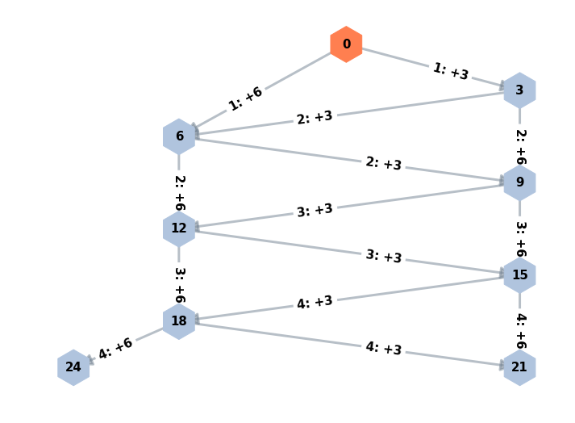

```python
import pydot
from networkx.drawing.nx_pydot import graphviz_layout

plt.figure(figsize=(12,9))
G3 = nx.MultiDiGraph()

G3.add_edges_from([('0','3'),('0','6')])
G3.add_edges_from([('3','6'),('3','9')])
G3.add_edges_from([('6','9'),('6','12')])
G3.add_edges_from([('9','12'),('9','15')])
G3.add_edges_from([('12','15'),('12','18')])
G3.add_edges_from([('15','18'),('15','21')])
G3.add_edges_from([('18','21'),('18','24')])

pos = graphviz_layout(G3, prog='dot')

edge_labels={('0','3'):'1: +3', ('0','6'):'1: +6',
             ('3','6'):'2: +3', ('3','9'):'2: +6', ('6','9'):'2: +3', ('6','12'):'2: +6',
             ('9','12'):'3: +3', ('9','15'):'3: +6', ('12','15'):'3: +3', ('12','18'):'3: +6',
             ('15','18'):'4: +3', ('15','21'):'4: +6', ('18','21'):'4: +3', ('18','24'):'4: +6'}

node_colors=['coral','lightsteelblue','lightsteelblue','lightsteelblue','lightsteelblue',
             'lightsteelblue','lightsteelblue','lightsteelblue','lightsteelblue']

nx.draw_networkx_edges(G3, pos, width=3, alpha=0.5, edge_color='slategray',
                       arrowsize=30, arrowstyle='-|>')
nx.draw_networkx_nodes(G3, pos, node_size=2000, node_shape='h', node_color=node_colors)

nx.draw_networkx_edge_labels(G, pos, edge_labels, label_pos=0.4,
                             font_size=15, font_weight='bold')
nx.draw_networkx_labels(G3, pos, font_size=15, font_weight='bold')

plt.axis('off')
plt.show()
```

6 кратно 3, поэтому на каждом этапе программы исполнитель может получить только два числа,

отличающихся от полученных на предыдущих этапах:

- Первая команда: 0 + 3 = 3; 0 + 6 = 6
- Вторая команда: 0 + 3 + 3 = 6; 0 + 3 + 6 = 9; 0 + 6 + 3 = 9; 0 + 6 + 6 = 12
- Третья команда: ...

Учитывая стартовое число 0, за 8 этапов можно получить

1 + 8 * 2 = 17 различных чисел в зависимости от выбора команды на каждом шаге.

3 is a multiplier of 6, therefore at each stage of the program the performer can get only two numbers

that differ from those obtained in the previous stages:

- The first command: 0 + 3 = 3; 0 + 6 = 6
- The second command: 0 + 3 + 3 = 6; 0 + 3 + 6 = 9; 0 + 6 + 3 = 9; 0 + 6 + 6 = 12
- The third command: ...

From the starting number 0, with 8 commands it is possible to get 1 + 8 * 2 = 17 different numbers,

depending on the choice of the command on each step.

```python
answer_dictionary[22]=str(1 + 8 * 2)
print("Answer:", answer_dictionary[22])
```

```
Answer: 17
```

[figure not shown]

Сколько существует различных наборов значений логических переменных $x_1, х_2, ... x_9, х_{10}$,

которые удовлетворяют всем перечисленным ниже условиям?

How many different sets of Boolean variables $x_1, х_2, ... x_9, х_{10}$ exist

that satisfy all of the following conditions?

$(\neg x_1 \equiv \neg x_2) \lor (\neg x_3 \equiv \neg x_4) = 1$

$(\neg x_3 \equiv \neg x_4) \lor (\neg x_5 \equiv \neg x_6) = 1$

$(\neg x_5 \equiv \neg x_6) \lor (\neg x_7 \equiv \neg x_8) = 1$

$(\neg x_7 \equiv \neg x_8) \lor (\neg x_9 \equiv \neg x_{10}) = 1$

В ответе **не нужно** перечислять все различные наборы значений $x_1, х_2, ... x_9, х_{10}$, при которых выполнена данная система равенств.

В качестве ответа вам нужно указать количество таких наборов.

The answer **does not need** to list all the different sets of values $x_1, х_2, ... x_9, х_{10}$ under which this system of equations is satisfied.

As an answer, you need to specify only the number of such sets.

```python
%%latex
$ ( \ (\neg x_1 \equiv \neg x_2) \lor (\neg x_3 \equiv \neg x_4) = 1 \ )  \iff
( \ (x_1 \equiv x_2) \lor (x_3 \equiv x_4) = 1 \ \iff
\neg ( x_1 \equiv x_2) \land \neg (x_3 \equiv x_4) = 0$
```

$ ( \ (\neg x_1 \equiv \neg x_2) \lor (\neg x_3 \equiv \neg x_4) = 1 \ ) \iff ( \ (x_1 \equiv x_2) \lor (x_3 \equiv x_4) = 1 \ \iff \neg ( x_1 \equiv x_2) \land \neg (x_3 \equiv x_4) = 0$

1)

Упростим систему логических уравнений. / Let's simplify the logical equations.

$( \ (\neg x_1 \equiv \neg x_2) \lor (\neg x_3 \equiv \neg x_4) = 1 \ ) \iff ( \ (x_1 \equiv x_2) \lor (x_3 \equiv x_4) = 1 \ \iff \neg ( x_1 \equiv x_2) \land \neg (x_3 \equiv x_4) = 0$

2)

Система будет иметь вид: / The system of equations will be:

$ \neg ( x_1 \equiv x_2) \land \neg (x_3 \equiv x_4) = 0$ **(1)**

$ \neg ( x_3 \equiv x_4) \land \neg (x_5 \equiv x_6) = 0$ **(2)**

$ \neg ( x_5 \equiv x_6) \land \neg (x_7 \equiv x_8) = 0$ **(3)**

$ \neg ( x_7 \equiv x_8) \land \neg (x_8 \equiv x_{10}) = 0$ **(4)**

3) Количество бинарных комбинаций из 10 цифр: / The number of binary combinations from 10 digits:

$2^{10}=1024$

4)

Тождество $(1)$ нарушается, только если $x_1 \neq x_2$ и $x_3 \neq x_4$ одновременно,

то есть необходимо исключить 4 набора переменных, в которых $(x_1, x_2, x_3, x_4)$ имеют вид (0,1,0,1), (0,1,1,0), (1,0,0,1), (1,0,1,0).

Таких наборов (с учетом комбинаций остальных 6 переменных) будет: $4*2^{6}$.

При этом возможных наборов сочетаний $(x_1, x_2, x_3, x_4)$ остается только 16 - 4 = 12: (0,0,0,1), (1,1,0,1), и т.д.

The identity $(1)$ is violated only if $x_1 \neq x_2$ and $x_3 \neq x_4$ simultaneously,

so it is necessary to exclude 4 sets of variables in which $(x_1, x_2, x_3, x_4)$ have the form (0,1,0,1), (0,1,1,0), (1,0,0,1), (1,0,1,0).

This kind of sets (taking into account combinations of the remaining 6 variables) will be $4 * 2 ^ {6}$.

In this case, we have less possible combinations $(x_1, x_2, x_3, x_4)$ - only 16 - 4 = 12: (0,0,0,1), (1,1,0,1), etc.

5)

Тождество $(2)$ нарушается, только если $x_3 \neq x_4$ и $x_5 \neq x_6$ одновременно,

то есть необходимо исключить 4 набора переменных, в которых $(x_3, x_4, x_5, x_6)$ имеют вид (0,1,0,1), (0,1,1,0), (1,0,0,1), (1,0,1,0).

$(x_7, x_8, x_9, x_{10})$ принимают любые значения (количество их комбинаций равно $2^4$),

а $(x_1, x_2)$ может иметь только 2 варианта (0,0) и (1,1), учитывая пункт 4).

Всего тождество $(2)$ могут нарушить: $2 * 4 * 2^{4}$ набора.

The identity $(2)$ is violated only if $x_3 \neq x_4$ and $x_5 \neq x_6$ simultaneously,

so it is necessary to exclude 4 sets of variables in which $(x_3, x_4, x_5, x_6)$ have the form (0,1,0,1), (0,1,1,0), (1,0,0,1), (1,0,1,0).

$(x_7, x_8, x_9, x_{10})$ takes any values (the number of their combinations is $2 ^ 4$),

and $(x_1, x_2)$ can have only 2 combinations (0,0) and (1,1), taking into account point 4).

In total, the identity $ (2) $ can be violated by: $2 * 4 * 2^{4}$ sets.

6)

Тождество $(3)$ нарушается, только если $x_5 \neq x_6$ и $x_7 \neq x_8$ одновременно,

то есть необходимо исключить 4 набора переменных, в которых $(x_5, x_6, x_7, x_8)$ имеют вид (0,1,0,1), (0,1,1,0), (1,0,0,1), (1,0,1,0).

$(x_3, x_4)$ может иметь только 2 варианта (0,0) и (1,1), учитывая пункт 5).

При этом переменные $(x_1, x_2)$ могут иметь все 4 возможных варианта сочетаний и переменные $(x_9, x_{10})$ аналогично.

Всего тождество $(3)$ могут нарушить: $4 * 2 * 4 * 4$ набора.

The identity $(3)$ is violated only if $ x_5 \neq x_6 $ and $ x_7 \neq x_8 $ simultaneously,

so it is necessary to exclude 4 sets of variables in which $(x_5, x_6, x_7, x_8)$ have the form (0,1,0,1), (0,1,1,0), (1,0,0,1), (1,0,1,0).

$(x_3, x_4)$ can have only 2 variants (0,0) and (1,1), taking into account point 5).

In this case, the variables $(x_1, x_2)$ can have all 4 possible variants of combinations and the variables $(x_9, x_{10})$ are similar.

In total, the identity $(3)$ can be violated by: $4 * 2 * 4 * 4$ sets.

7)

Тождество $(4)$ нарушается, только если $x_7 \neq x_8$ и $x_9 \neq x_{10}$ одновременно,

то есть необходимо исключить 4 набора переменных, в которых $(x_7, x_8, x_9, x_{10})$ имеют вид (0,1,0,1), (0,1,1,0), (1,0,0,1), (1,0,1,0).

$(x_5, x_6)$ = (0,0) или (1,1), учитывая пункт 6).

При этом переменные $(x_1, x_2, x_3, x_4)$ имеют только 12 вариантов изменений, учитывая пункт 4).

Всего тождество $(4)$ могут нарушить: $12 * 2 * 4$ набора.

The identity $(4)$ is violated only if $x_7 \neq x_8 $ and $ x_9 \neq x_{10}$ simultaneously,

so you need to exclude 4 sets of variables in which $(x_7, x_8, x_9, x_{10})$ have the form (0,1,0,1), (0,1,1,0), (1,0,0,1), (1,0,1,0).

$(x_5, x_6)$ = (0,0) or (1,1), taking into account point 6).

In this case, the variables $(x_1, x_2, x_3, x_4)$ have only 12 variants of changes, taking into account point 4).

In total, the identity $(4)$ can be violated by $12 * 2 * 4$ sets.

```python
2 ** 10 - 4 * 2 ** 6 - 2 * 4 * 2 ** 4 - 4 * 2 * 4 * 4 - 12 * 2 * 4
```

```
416
```

```python
# Check the decision method
import numpy
import itertools
n = 10
binary_combinations = numpy.array(list(itertools.product([0, 1], repeat=n)))
result = []

def logical_function(k,l,m,n):
    return bool( ((not k) == (not l)) or ((not m) == (not n)) )

for el in binary_combinations:
    e1 = logical_function(el[0],el[1],el[2],el[3])
    e2 = logical_function(el[2],el[3],el[4],el[5])
    e3 = logical_function(el[4],el[5],el[6],el[7])
    e4 = logical_function(el[6],el[7],el[8],el[9])
    result.append(e1 and e2 and e3 and e4)

answer_dictionary[23]=str(sum(result))
print("Answer:", answer_dictionary[23])
```

```
Answer: 416
```

## Часть 2 Part 2

[figure not shown]

Требовалось написать программу, которая вводит с клавиатуры координаты точки на плоскости (х, у — действительные числа)

и определяет принадлежность точки заштрихованной области.

Программист торопился и написал программу неправильно.

Последовательно выполните следующее:

1. Приведите пример таких чисел х, у при которых программа работает неправильно.
2. Укажите, как нужно доработать программу, чтобы не было случаев её неправильной работы.

(Это можно сделать несколькими способами, поэтому можно указать любой способ доработки исходной программы).

Python

R

```python
x = float(input("x "))
y = float(input("y "))

if y <= -x * x:
    if y <= 0:
        if y >= -x - 2:
            print('принадлежит')
        else:
            print('не принадлежит')
```

```r
x <- as.numeric(readline("x "))
y <- as.numeric(readline("y "))

if (y <= -x * x) {
    if (y <= 0) {
        if (y >= -x - 2){
            print('принадлежит')
        } else {
            print('не принадлежит')
        }
    }
}
```

It was required to write a program that enters from the keyboard the coordinates of the point on the plane (x, y are real numbers)

and determines the belonging of the point to the shaded region.

The programmer was in a hurry and wrote the program incorrectly.

Do the following sequentially:

1. Give an example of such numbers x, y for which the program does not work correctly.
2. Indicate how you need to refine the program so that there are no cases of its improper operation.

(This can be done in several ways, so you can specify any way to refine the source program).

**Note**: `принадлежит`=`belongs`; `не принадлежит`=`does not belong`.

#### Неправильный вариант на Си и Паскале

Работает некорректно, если выполнены условия $y \leq -x*x$ и $y \leq 0$, но не выполнено $y \geq -x-2$. Например, для (-1,-3).

#### Wrong options on C and Pascal

It works incorrectly if the conditions $ y \leq -x * x $ and $ y \leq 0 $ are fulfilled, but $ y \geq -x-2 $ is not fulfilled. For example, for (-1, -3).

```python
x = float(input("x "))
y = float(input("y "))
if y <= -x*x:
    if y <= 0:
        if y >= -x-2:
            print('принадлежит')
else:
    print('не принадлежит')
```

```
x -1
y -3
```

#### Неправильный вариант на Бейсике и Алгоритмическом языке

Работает некорректно, если не выполнены условия $y \leq -x*x$ или $y \leq 0$. Например, для (-2,-3).

#### Wrong options on BASIC and Algorithmic Language

It works incorrectly if the conditions $ y \leq -x * x $ or $ y \leq 0 $ are not fulfilled. For example, for (-2, -3).

```python
x = float(input("x "))
y = float(input("y "))
if y <= -x*x:
    if y <= 0:
        if y >= -x-2:
            print('принадлежит')
        else:
            print('не принадлежит')
```

```
x -2
y -3
```

#### Верный вариант программы

#### The right variant og the program

```python
x = float(input("x "))
y = float(input("y "))
if ((y <= -x*x)  or ((y <= 0) and (y > -x*x))) and (y >= -x-2):
    print('принадлежит')
else:
    print('не принадлежит')
```

```
x -1
y -3
не принадлежит
```

```python
x = float(input("x "))
y = float(input("y "))
if ((y <= -x*x)  or ((y <= 0) and (y > -x*x))) and (y >= -x-2):
    print('принадлежит')
else:
    print('не принадлежит')
```

```
x -2
y -3
не принадлежит
```

```python
x = float(input("x "))
y = float(input("y "))
if ((y <= -x*x)  or ((y <= 0) and (y > -x*x))) and (y >= -x-2):
    print('принадлежит')
else:
    print('не принадлежит')
```

```
x 0
y -1
принадлежит
```

```python
answer_dictionary[24]=['C and Pascal: (-1,-3); BASIC and Algorithmic Language: (-2,-3)',
                       'if ((y <= -x*x)  or ((y <= 0) and (y > -x*x))) and (y >= -x-2):']
print("Answer:", answer_dictionary[24])
```

```
Answer: ['C and Pascal: (-1,-3); BASIC and Algorithmic Language: (-2,-3)', 'if ((y <= -x*x)  or ((y <= 0) and (y > -x*x))) and (y >= -x-2):']
```

[figure not shown]

Дан вещественный массив из 40 элементов. Элементы массива могут принимать произвольные значения.

Опишите на русском языке или на одном из языков программирования алгоритм,

который находит и выводит минимальный положительный элемент массива или сообщение, что такого элемента нет.

Исходные данные объявлены так, как показано ниже.

Запрещается использовать переменные, не описанные ниже, но разрешается не использовать часть из них.

- Объявляем массив А из 40 элементов.
- Объявляем целочисленные переменные I, J, и вещественную переменную MIN.
- В цикле от 1 до 40 вводим элементы массива А с 1-го по 40-й.
- ...

В качестве ответа вам необходимо привести фрагмент программы (или описание алгоритма на естественном языке), который должен находиться на месте многоточия.

Вы можете записать решение также на другом языке программирования (укажите название и используемую версию языка программирования, например `Borland Pascal 7.0`) или в виде блок-схемы.

В этом случае вы должны использовать те же самые исходные данные и переменные, какие были предложены в условии (например, в образце, записанном на естественном языке).

Python

R

```python
N = 40
A = []
# use integer variables I,J and a real variable MIN

for I in range(N):
    A.append(float(input()))
...
```

```r
N <- 40
A <- vector(length=N)
#use integer variables I,J and a real variable MIN

for (I in 1:N){
    A[I] <- as.numeric(readline())
...
}
```

A real array of 40 elements is given. Array elements can take arbitrary values.

Describe in the Russian / English language or in one of the programming languages an algorithm

that finds and displays the minimum positive element of the array or a message that there is no such element.

The original data is declared as shown below.

It is forbidden to use variables not described below, but it is allowed not to use part of them.

- Declare an array A of 40 elements.
- Declare the integer variables I, J, and the real variable MIN.
- In the cycle from 1 to 40, the elements of array A are entered from the 1st to the 40th.
- ...

As an answer, you need to bring the program fragment (or description of the algorithm in the natural language), which should be in place of the ellipsis.

You can also write the solution in another programming language (specify the name and the version of the programming language used: for example, `Borland Pascal 7.0`) or as a flowchart.

In this case, you must use the same source data and variables that were proposed in the condition (for example, in a sample written in the natural language).

```python
import sys
version = 'python '+str(sys.version_info[0])+'.'+str(sys.version_info[1])
```

```python
# The first method
N = 40
A = []
MIN = 10**100

for I in range(N):
    A.append(float(input()))

    if A[I] > 0 and A[I] < MIN:
        MIN = A[I]

if MIN == 10**100:
    print("There are no positive numbers in the array")
else:
    print(MIN)
```

```
1.24
0.5
-0.7
10
20
3302
-34.56
-90.3
91
29
35
480
-2958
13002
-4504
-235.99
-5043.2
49503
456.4
98.4
9812.3
-901
-236.4
-399.6
304
24.9
-9284
-876.5
26.845
3999.4
-15
-293.1
111
20578
-30982
-856
-43.6
156.89
234567
-905.43
0.5
```

```python
print("Create an array of 40 float numbers.")
N = 40
A = numpy.zeros(N)

for I in range(N):
    A[I] = float(input(" "))
print(A)
```

```
Create an array of 40 float numbers.
 1.24
 0.5
 -0.7
 10
 -15.3
 20
 3302
 -34.56
 -90.3
 91
 29
 35
 480
 -2958
 -34.2
 -12.38
 223
 206
 1290
 -34.77
 -902
 -12999
 2943
 -34.5
 3920.5
 685.7
 294.3
 1902.4
 -203.3
 -1023.2
 -103.5
 -4930.5
 23
 984
 893.4
 29034
 90283.5
 -102.2
 -2224
 39485
[ 1.24000e+00  5.00000e-01 -7.00000e-01  1.00000e+01 -1.53000e+01
  2.00000e+01  3.30200e+03 -3.45600e+01 -9.03000e+01  9.10000e+01
  2.90000e+01  3.50000e+01  4.80000e+02 -2.95800e+03 -3.42000e+01
 -1.23800e+01  2.23000e+02  2.06000e+02  1.29000e+03 -3.47700e+01
 -9.02000e+02 -1.29990e+04  2.94300e+03 -3.45000e+01  3.92050e+03
  6.85700e+02  2.94300e+02  1.90240e+03 -2.03300e+02 -1.02320e+03
 -1.03500e+02 -4.93050e+03  2.30000e+01  9.84000e+02  8.93400e+02
  2.90340e+04  9.02835e+04 -1.02200e+02 -2.22400e+03  3.94850e+04]
```

```python
# The second method
if len(A[numpy.where(A > 0)]) == 0:
    print("There are no positive numbers in the array")
else:
    print(numpy.min(A[A > 0]))
```

```
0.5
```

```python
program_fragment = \
"""
N = 40
A = []
MIN = 10**100

for I in range(N):
    A.append(float(input()))

# The fragment instead of the ellipsis
    if A[I] > 0 and A[I] < MIN:
        MIN = A[I]

if MIN == 10**100:
    print("There are no positive numbers in the array")
else:
    print(MIN)
"""
```

```python
answer_dictionary[25]=[version, program_fragment]
print("Answer:", answer_dictionary[25])
```

```
Answer: ['python 3.6', '\nN = 40\nA = []\nMIN = 10**100\n\nfor I in range(N):\n    A.append(float(input()))\n    \n# The fragment instead of the ellipsis    \n    if A[I] > 0 and A[I] < MIN:\n        MIN = A[I]\n        \nif MIN == 10**100:\n    print("There are no positive numbers in the array")\ne…
```

[figure not shown]

Два игрока играют в следующую игру. На координатной плоскости в точке (1,0) стоит фишка. Игроки ходят по очереди.

Ход состоит в том, что игрок перемещает фишку из точки с координатами (x, у) в одну из трёх точек:

- в точку с координатами (х + 3, у),
- в точку (х, у + 3),
- в точку (x + 3, у + 3).

Выигрывает игрок, после хода которого, расстояние по прямой от фишки до точки с координатами (0, 0) не меньше 13 единиц.

Кто выигрывает при безошибочной игре обоих игроков — игрок, делающий первый ход, или игрок, делающий второй ход?

Какими должны быть ходы выигрывающего игрока? Ответ обоснуйте.

Two participants play the next game. On the coordinate plane at the point (1,0) there is a game chip. Players move the chip by turns.

One action consists in the fact that the participant moves the chip from the point with the coordinates (x, y) to one of three points:

- to the point with the coordinates (x + 3, y),
- to the point (x, y + 3),
- to the point (x + 3, y + 3).

The player wins, if after his move the distance from the chip to the point with coordinates (0, 0) is not less than 13 units.

Who wins with an unmistakable game of both participants - the player making the first move, or the player making the second move? What should be the moves of the winning player? Justify the answer.

Побеждает II игрок. / The second player wins.

Его выигрышная стратегия: / His winning strategy:

I: $(1,0)-1 \to (4,0)-4 \; (x + 3) \lor (1,0)-1 \to (1,3)-3.2 \; (y + 3) \lor (1,0)-1 \to (4,3)-5 \; (x + 3, y + 3)$.

II: $(4,0)-4 \to (7,3)-7.6 \; (x + 3, y + 3) \lor (1,3)-3.2 \to (4,6)-7.2 \; (x + 3, y + 3) \lor (4,3)-5 \to (7,3)-7.6 \; (x + 3)$

I:

$(7,3)-7.6 \to (10,3)-10.4 \; (x + 3) \lor (7,3)-7.6 \to (7,6)-9.2 \; (y + 3) \lor (7,3)-7.6 \to (10,6)-11.7 \; (x + 3, y + 3)$.

$\lor$

$(4,6)-7.2 \to (7,6)-9.2 \; (x + 3) \lor (4,6)-7.2 \to (4,9)-9.8 \; (y + 3) \lor (4,6)-7.2 \to (7,9)-11.4 \; (x + 3, y + 3)$.

II:

$(4,9)-9.8 \to (7,12)-13.9 \; (x + 3, y + 3) \lor (7,6)-9.2 \to (10,9)-13.5 \; (x + 3, y + 3) \lor$

$(7,9)-11.4 \to (10,12)-15.6 \; (x + 3, y + 3) \lor (10,3)-10.4 \to (13,6)-14.3 \; (x + 3, y + 3) \lor$

$(10,6)-11.7 \to (13,9)-15.8$

Граф соответствует дереву игры. / The graph corresponds to the game tree.

На рёбрах дерева указывано, кто делает ход, в узлах — позиция игры и расстояние до (0, 0).

The edges of the tree indicate who is making the move, the nodes - a position of the game and a distance to (0, 0).

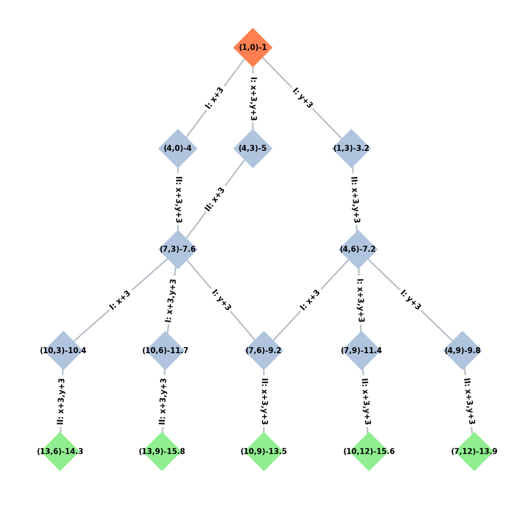

```python
import pydot
from networkx.drawing.nx_pydot import graphviz_layout

plt.figure(figsize=(18,18))
G4 = nx.MultiDiGraph()

G4.add_edges_from([('(1,0)-1','(4,0)-4'),('(1,0)-1','(1,3)-3.2'),('(1,0)-1','(4,3)-5')])

G4.add_edges_from([('(4,0)-4','(7,3)-7.6')])
G4.add_edges_from([('(1,3)-3.2','(4,6)-7.2')])
G4.add_edges_from([('(4,3)-5','(7,3)-7.6')])

G4.add_edges_from([('(7,3)-7.6','(10,3)-10.4'),('(7,3)-7.6','(7,6)-9.2'),('(7,3)-7.6','(10,6)-11.7')])
G4.add_edges_from([('(4,6)-7.2','(7,6)-9.2'),('(4,6)-7.2','(4,9)-9.8'),('(4,6)-7.2','(7,9)-11.4')])

G4.add_edges_from([('(4,9)-9.8','(7,12)-13.9')])
G4.add_edges_from([('(7,6)-9.2','(10,9)-13.5')])
G4.add_edges_from([('(7,9)-11.4','(10,12)-15.6')])
G4.add_edges_from([('(10,3)-10.4','(13,6)-14.3')])
G4.add_edges_from([('(10,6)-11.7','(13,9)-15.8')])

pos = graphviz_layout(G4, prog='dot')

edge_labels={('(1,0)-1','(4,0)-4'):'I: x+3', ('(1,0)-1','(1,3)-3.2'):'I: y+3',
             ('(1,0)-1','(4,3)-5'):'I: x+3,y+3', ('(4,0)-4','(7,3)-7.6'):'II: x+3,y+3',
             ('(1,3)-3.2','(4,6)-7.2'):'II: x+3,y+3', ('(4,3)-5','(7,3)-7.6'):'II: x+3',
             ('(7,3)-7.6','(10,3)-10.4'):'I: x+3', ('(7,3)-7.6','(7,6)-9.2'):'I: y+3',
             ('(7,3)-7.6','(10,6)-11.7'):'I: x+3,y+3', ('(4,6)-7.2','(7,6)-9.2'):'I: x+3',
             ('(4,6)-7.2','(4,9)-9.8'):'I: y+3', ('(4,6)-7.2','(7,9)-11.4'):'I: x+3,y+3',
             ('(4,9)-9.8','(7,12)-13.9'):'II: x+3,y+3', ('(7,6)-9.2','(10,9)-13.5'):'II: x+3,y+3',
             ('(7,9)-11.4','(10,12)-15.6'):'II: x+3,y+3', ('(10,3)-10.4','(13,6)-14.3'):'II: x+3,y+3',
             ('(10,6)-11.7','(13,9)-15.8'):'II: x+3,y+3'}

node_colors=['coral','lightsteelblue','lightsteelblue','lightsteelblue',
             'lightsteelblue','lightsteelblue','lightsteelblue','lightsteelblue',
             'lightsteelblue','lightsteelblue','lightsteelblue','lightgreen',
             'lightgreen','lightgreen','lightgreen','lightgreen']

nx.draw_networkx_edges(G4, pos, width=3, alpha=0.5, edge_color='slategray',
                       arrowsize=30, arrowstyle='-|>')
nx.draw_networkx_nodes(G4, pos, node_size=3000, node_shape='D', node_color=node_colors)

nx.draw_networkx_edge_labels(G4, pos, edge_labels,
                             font_size=15, font_weight='bold')
nx.draw_networkx_labels(G4, pos, font_size=15, font_weight='bold')

plt.axis('off')
plt.show()
```

```python
answer1='The second player'
answer2="""
The winning strategy:
if the first step of the first player is (x+3, y+3) =>
the second player moves (x+3, y) after that
and moves (x+3, y+3) in other cases
"""

answer_dictionary[26]=[answer1, answer2]
print("Answer:", answer_dictionary[26])
```

```
Answer: ['The second player', '\nThe winning strategy: \nif the first step of the first player is (x+3, y+3) => \nthe second player moves (x+3, y) after that \nand moves (x+3, y+3) in other cases\n']
```

[figure not shown]

После единых выпускных экзаменов по информатике в район пришла информация о том, какой ученик какой школы сколько баллов набрал.

Районный методист решила выяснить номера школ, ученики которых набрали средний балл по школе больший, чем районный средний балл (все средние баллы вычисляются с точностью до целых).

Программа должна вывести на экран номера таких школ в любом порядке.

Если такая школа окажется только одна — вывести также средний балл по этой школе с указанием, что это средний балл.

Напишите эффективную, в том числе и по используемой памяти, программу (укажите используемую версию языка программирования, например, `Borland Pascal 7.0`), которая должна вывести на экран требуемую информацию.

Известно, что информатику сдавало больше 5-ти учеников района. Также известно, что в районе школы с некоторыми номерами не существуют.

На вход программе сначала подается число учеников, сдававших экзамен. В каждой из следующих N строк находится информация об учениках в формате:

- `<Фамилия> <Имя> <Номер школы> <Количество баллов>`,

где `<Фамилия>` — строка, состоящая не более, чем из 30 символов без пробелов, `<Имя>` — строка, состоящая не более, чем из 20 символов без пробелов, `<Номер школы>` — целое число в диапазоне от 1 до 99, `<Количество баллов>` — целое число диапазоне от 1 до 100. Эти данные записаны через пробел, причём ровно один между каждой парой (то есть, всего по три пробела в каждой строке).

Пример входной строки:

- `Иванов Иван 50 87`

Пример выходных данных:

- `5 50 74 87`

Другой вариант выходных данных:

- `7`
- `Средний балл = 74`

After the final examinations in informatics, information was received in the district about which pupil of which school scored how many points.

The District Methodist decided to find out the numbers of schools which students had an average score for the school greater than the regional average score (all average scores are calculated to the nearest whole).

The program should display the numbers of such schools, in any order.

If such a school is only one the program should print out also the average score for this school, indicating that this is the average score.

Write an effective program, including the memory used (specify the version of the programming language used, for example, `Borland Pascal 7.0`), which should display the required information.

It is known that more than 5 pupils of the district handed in computer science. It is also known that in the district some school numbers do not exist.

At the entrance of the program, the number of students who pass the exam is first presented. Each of the following N lines contains information about students in the format:

- `<Surname> <Name> <School number> <Score>`,

where `<Surname>` is a string consisting of not more than 30 characters without spaces, `<Name>` - a string consisting of not more than 20 characters without spaces, `<School number>` - an integer in the range from 1 to 99, `<Score>` - an integer between 1 and 100. These data are written with a white space, with exactly one between each pair (that is, only three spaces per line).

Example of an input line:

- `Ivanov Ivan 50 87`

Example of an output line:

- `5 50 74 87`

Another variant of the output data:

- `7`
- `Average Score = 74`

Пример персональных данных.

1. Аверин Алексей 7 78
2. Бодрова Екатерина 38 81
3. Бондарев Максим 53 65
4. Вершинин Денис 7 87
5. Воронова Галина 7 76
6. Газиев Марат 38 83
7. Грачев Иван 38 67
8. Есин Руслан 53 88
9. Колесникова Мария 38 74
10. Лескова Анна 53 83
11. Мельников Роман 38 77
12. Морозова Жанна 53 88
13. Нестерова Роза 38 81
14. Нигматулин Ринат 7 72
15. Носиков Илья 53 88
16. Ольховский Дмитрий 7 79
17. Петренко Дарья 7 82
18. Робертсон Артур 38 73
19. Стариков Кирилл 53 70
20. Терехов Леонид 7 84

```python
# без использования импортируемых модулей
N = int(input("Число учеников, сдававших экзамен: "))
school_numbers = list(range(1,100))
average_scores = 100 * [0]
numbers_of_students = 100 * [0]
district_average_score = 0

print("Персональные данные в формате: ")
print("<Фамилия><пробел><Имя><пробел><Номер школы><пробел><Количество баллов>")
print(18*"=-= ")

for i in range(1,N+1):
    print(("{} ученик").format(i))
    string = input().split()
    school_number = int(string[2])
    score = int(string[3])

    numbers_of_students[school_number] += 1

    average_scores[school_number] = \
    average_scores[school_number] * (1 - 1 / numbers_of_students[school_number]) + \
    score / numbers_of_students[school_number]

    district_average_score += score / N

h_school_numbers = ''
h_average_scores = ''
district_average_score = round(district_average_score)

for i in range(1,100):
    if numbers_of_students[i] != 0:
        if round(average_scores[i]) > district_average_score:
            h_school_numbers += str(i) + ' '
            h_average_scores += str(round(average_scores[i])) + ' '

if len(h_school_numbers.split()) == 1:
    print(h_school_numbers + '\nAverage Score = ' + h_average_scores)
else:
    print(h_school_numbers)
```

```
Число учеников, сдававших экзамен: 20
Персональные данные в формате:
<Фамилия><пробел><Имя><пробел><Номер школы><пробел><Количество баллов>
=-= =-= =-= =-= =-= =-= =-= =-= =-= =-= =-= =-= =-= =-= =-= =-= =-= =-=
1 ученик
Аверин Алексей 7 78
2 ученик
Бодрова Екатерина 38 81
3 ученик
Бондарев Максим 53 65
4 ученик
Вершинин Денис 7 87
5 ученик
Воронова Галина 7 76
6 ученик
Газиев Марат 38 83
7 ученик
Грачев Иван 38 67
8 ученик
Есин Руслан 53 88
9 ученик
Колесникова Мария 38 74
10 ученик
Лескова Анна 53 83
11 ученик
Мельников Роман 38 77
12 ученик
Морозова Жанна 53 88
13 ученик
Нестерова Роза 38 81
14 ученик
Нигматулин Ринат 7 72
15 ученик
Носиков Илья 53 88
16 ученик
Ольховский Дмитрий 7 79
17 ученик
Петренко Дарья 7 82
18 ученик
Робертсон Артур 38 73
19 ученик
Стариков Кирилл 53 70
20 ученик
Терехов Леонид 7 84
7 53
```

```python
program=\
"""
N = int(input("Число учеников, сдававших экзамен: "))
school_numbers = list(range(1,100))
average_scores = 100 * [0]
numbers_of_students = 100 * [0]
district_average_score = 0

print("Персональные данные в формате: ")
print("<Фамилия><пробел><Имя><пробел><Номер школы><пробел><Количество баллов>")
print(18*"=-= ")

for i in range(1,N+1):
    print(("{} ученик").format(i))
    string = input().split()
    school_number = int(string[2])
    score = int(string[3])

    numbers_of_students[school_number] += 1

    average_scores[school_number] = \
    average_scores[school_number] * (1 - 1 / numbers_of_students[school_number]) + \
    score / numbers_of_students[school_number]

    district_average_score += score / N

h_school_numbers = ''
h_average_scores = ''
district_average_score = round(district_average_score)

for i in range(1,100):
    if numbers_of_students[i] != 0:
        if round(average_scores[i]) > district_average_score:
            h_school_numbers += str(i) + ' '
            h_average_scores += str(round(average_scores[i])) + ' '

if len(h_school_numbers.split()) == 1:
    print(h_school_numbers + '\nAverage Score = ' + h_average_scores)
else:
    print(h_school_numbers)
"""
```

```python
answer_dictionary[27]=[version, program]
print("Answer:", answer_dictionary[27])
```

```
Answer: ['python 3.6', '\nN = int(input("Число учеников, сдававших экзамен: "))\nschool_numbers = list(range(1,100))\naverage_scores = 100 * [0]\nnumbers_of_students = 100 * [0]\ndistrict_average_score = 0\n\nprint("Персональные данные в формате: ")\nprint("<Фамилия><пробел><Имя><пробел><Номер школы…
```

```python
# с использованием импортируемых модулей
import pandas

N = int(input("Число учеников, сдававших экзамен: "))
print("Персональные данные в формате: ")
print("<Фамилия><пробел><Имя><пробел><Номер школы><пробел><Количество баллов>")
print(18*"=-= ")

df = pandas.DataFrame(index=range(1,N+1,1),
                      columns=['Фамилия', 'Имя', 'Номер школы', 'Количество баллов'])
df = df.fillna(0)

for i in range(1,N+1,1):
    print(("{} ученик").format(i))
    df.loc[i] = input("").split()
```

```
Число учеников, сдававших экзамен: 20
Персональные данные в формате:
<Фамилия><пробел><Имя><пробел><Номер школы><пробел><Количество баллов>
=-= =-= =-= =-= =-= =-= =-= =-= =-= =-= =-= =-= =-= =-= =-= =-= =-= =-=
1 ученик
Аверин Алексей 7 78
2 ученик
Бодрова Екатерина 38 81
3 ученик
Бондарев Максим 53 65
4 ученик
Вершинин Денис 7 87
5 ученик
Воронова Галина 7 76
6 ученик
Газиев Марат 38 83
7 ученик
Грачев Иван 38 67
8 ученик
Есин Руслан 53 88
9 ученик
Колесникова Мария 38 74
10 ученик
Лескова Анна 53 83
11 ученик
Мельников Роман 38 77
12 ученик
Морозова Жанна 53 88
13 ученик
Нестерова Роза 38 81
14 ученик
Нигматулин Ринат 7 72
15 ученик
Носиков Илья 53 88
16 ученик
Ольховский Дмитрий 7 79
17 ученик
Петренко Дарья 7 82
18 ученик
Стариков Кирилл 53 70
19 ученик
Робертсон Артур 38 73
20 ученик
Терехов Леонид 7 84
```

```python
df['Количество баллов']=df['Количество баллов'].astype('int32')
df['Номер школы']=df['Номер школы'].astype('int32')
avg_score = round(df['Количество баллов'].mean(),0)

schools, avg_school_scores = '', []
for school in df['Номер школы'].unique():
    avg_school_score = df[df['Номер школы']==school]['Количество баллов'].mean()
    if avg_school_score > avg_score:
        schools+=' '
        schools+=str(school)
        avg_school_scores.append(round(avg_school_score,0))

num_school_list = [int(el) for el in schools[1:].split()]

if len(num_school_list) == 1:
    print(num_school_list[0], "\nСредний бал = ", int(avg_school_scores[0]))
else:
    print(schools)
```

```
 7 53
```

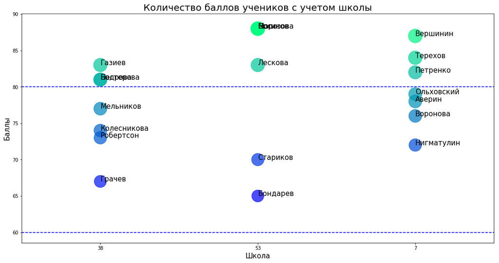

```python
plt.figure(figsize=(18,9))
plt.axhline(80, c='b', ls='--')
plt.axhline(60, c='b', ls='--')

schools = df['Номер школы'].apply(str)

plt.scatter(x=schools, y=df['Количество баллов'],
            c=df['Количество баллов'], s=df['Количество баллов']*10,
            alpha=0.7, cmap=plt.cm.winter)

labels = df['Фамилия']
for i in range (20):
    xy=(schools[i+1],df['Количество баллов'][i+1])
    plt.annotate(labels[i+1],xy,fontsize=15)

plt.xlim(-0.5,2.5)
plt.xlabel('Школа', fontsize=15)
plt.ylabel('Баллы', fontsize=15)
plt.title("Количество баллов учеников с учетом школы", fontsize=20);
```

## Ответы Answers

```python
answer_dictionary
```

```
{1: '11010110',
 2: '34',
 3: '2',
 4: '5',
 5: 'CDBACED',
 6: 'BC',
 7: '=$B2+D$2',
 8: '127',
 9: '1',
 10: '243',
 11: '21',
 12: 'EADCGBF',
 13: '180',
 14: '4',
 15: '30',
```

[output cut: 16 more lines]